# Giving By Major

Michael Pawlus

Friday, July 10, 2015

### Looking at Giving Trends by Major

To perform this analysis, you will need a csv file with the unique IDs for your alumni as well as their majors and if they are a donor or not as a binary variable (1 or 0). You can also add in any other variables that you want to include.

First, load the ggplot2 library (use install.packages(“ggplot2”) if you don’t have this package yet. We will use this for plotting. Also, set the working directory to the folder where this csv file is located:

```r
library(ggplot2)
setwd("C://users/pawlusm/Desktop/decTree/mokan/giving_by_major_comparison")
```

Then, read the file into R:

```r
ad <- read.csv("alum_donor_factors_no_names.csv")
```

Use the summary function to look for any outliers:

```r
summary(ad)     ## summary of the data
```

```
##      coreid         aff_total      coresex    coreprefyr       Degree
##  Min.   :  1923   Min.   :  0.00   F:1562   Min.   :1967   BS     :1179
##  1st Qu.:102878   1st Qu.:  4.00   M:1316   1st Qu.:1986   BBA    : 472
##  Median :129104   Median :  7.00            Median :2000   BA     : 364
##  Mean   :310682   Mean   : 10.17            Mean   :1997   MED    : 239
##  3rd Qu.:597856   3rd Qu.: 11.00            3rd Qu.:2009   MBA    : 127
##  Max.   :727273   Max.   :248.00            Max.   :2014   MPA    :  83
##                                                            (Other): 414
##                    Major           fy14              donor
##  Business General     : 148   Min.   :    0.27   Min.   :1
##  Accounting           : 147   1st Qu.:   25.00   1st Qu.:1
##  General Education    : 139   Median :   50.00   Median :1
##  Public Administration: 118   Mean   :  351.06   Mean   :1
##  Nursing              : 108   3rd Qu.:  200.00   3rd Qu.:1
##  Finance              : 105   Max.   :51245.54   Max.   :1
##  (Other)              :2113
```

I want to use affinity score or engagement score for my x-axis to see the impact of affinity on giving so I am going to trim my dataset so that I don’t get heavily skewed results from outliers and also to improve readability.

```r
ad2 <- ad[ad$aff_total<16,]
```

Next, let’s create a table of all the majors in the dataset to see which ones have the most representations and then pull a top ten list.

```r
maj_tbl <- aggregate(coreid ~ Major, data = ad2, length)
head(maj_tbl[order(-maj_tbl$coreid),], n= 10)
```

```
##                     Major coreid
## 2              Accounting    129
## 47      General Education    116
## 18       Business General    109
## 92                Nursing     94
## 105            Psychology     92
## 84             Management     89
## 45                Finance     88
## 85              Marketing     85
## 106 Public Administration     85
## 100    Physical Education     83
```

From this table, pull a few majors to compare. I will select three.

```r
ad4 <- ad2[ad2$Major %in% c("Accounting","Nursing","Psychology"),]
```

Then, use a faceted plot to compare giving between majors as well as the relative impact of engagement.

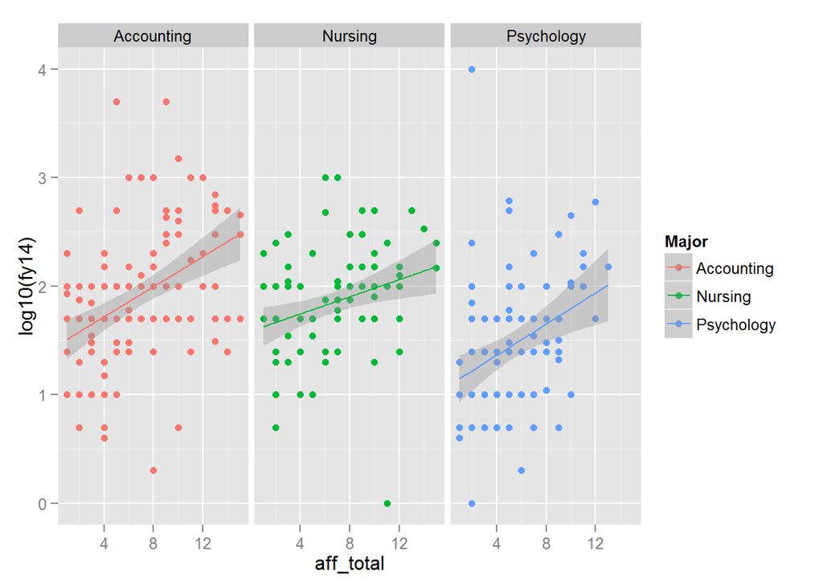

```r
qplot(aff_total, log10(fy14), data = ad4, color = Major, facets=~Major) + stat_smooth(method="lm")
```